# What is the impact of the Airline, the Origin and Destination Airports, the Week day, the Month Day and the Time of the flight in delays and cancellations?

## Let's find out...

# How do Airlines compare on Flight Cancellation percentages?

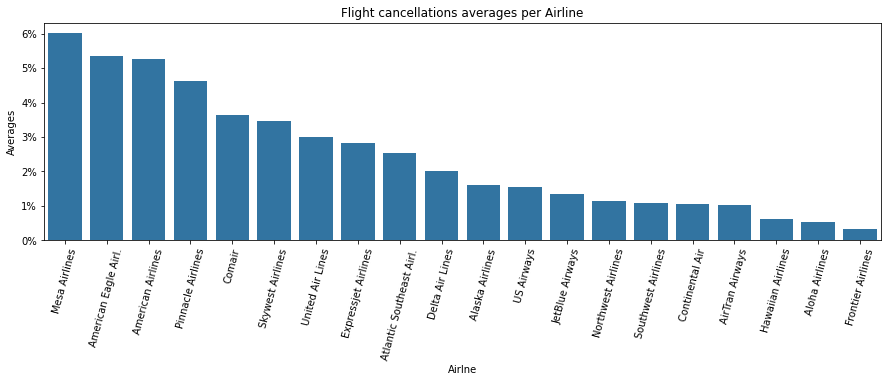

```python
plt.figure(figsize=(15,4))
base_color = sb.color_palette()[0]

AvgCancellationsPerAirline = delays.groupby('UniqueCarrierFull').Cancelled.mean().sort_values(ascending = False)
sb.barplot(x=AvgCancellationsPerAirline.index,y=AvgCancellationsPerAirline.values,color=base_color)
plt.gca().yaxis.set_major_formatter(PercentFormatter(1, decimals = 0))
plt.xlabel('Airlne')
plt.xticks(rotation = 75)
plt.ylabel('Averages')
plt.title('Flight cancellations averages per Airline');
```

## Messa Airlines ranks first while Frontier Airlines last.

##### It's worth mentioning Hawaiian and Aloha Airlines which are ranked very low as well.

# How do Days of Week compare on Flight Cancellation percentages?

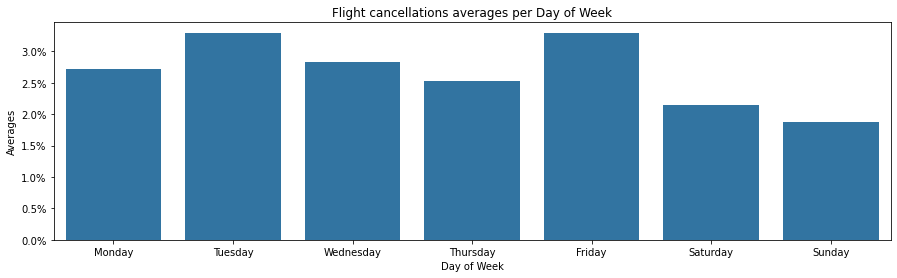

```python
plt.figure(figsize=(15,4))

AvgCancellationsPerDoW = delays.groupby('DayOfWeek').Cancelled.mean()
sb.barplot(x=AvgCancellationsPerDoW.index,y=AvgCancellationsPerDoW.values,color=base_color)
plt.gca().yaxis.set_major_formatter(PercentFormatter(1, decimals = 1))
plt.xlabel('Day of Week')
plt.ylabel('Averages')
plt.title('Flight cancellations averages per Day of Week');
```

## Friday ranks first with Tuesday being a close second!

# How do Days of Month compare on Flight Cancellation percentages?

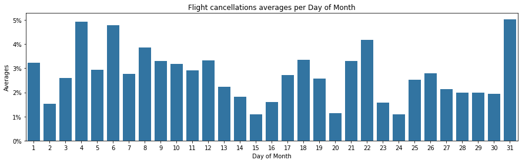

```python
plt.figure(figsize=(15,4))

AvgCancellationsPerDoM = delays.groupby('DayofMonth').Cancelled.mean()

sb.barplot(x=AvgCancellationsPerDoM.index,y=AvgCancellationsPerDoM.values,color=base_color)
plt.gca().yaxis.set_major_formatter(PercentFormatter(1, decimals = 0))
plt.xlabel('Day of Month')
plt.ylabel('Averages')
plt.title('Flight cancellations averages per Day of Month');
```

## The 4th, 6th and 31st from each month have the most cancellations throughout the month.

##### 15th, 20th and 24th are worth mentioning as we find them in the lowest end of the days with flight cancellations.

# How do Origin Airports compare on Flight Cancellation percentages?

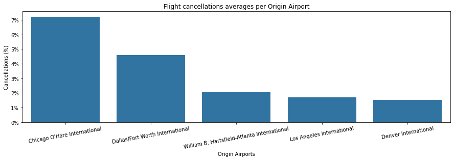

```python
plt.figure(figsize=(15,4))

AvgCancellationsPerOrAirports = top_five_origin_airports.groupby('Origin').Cancelled.mean().sort_values(ascending = False)

sb.barplot(x=AvgCancellationsPerOrAirports.index,y=AvgCancellationsPerOrAirports.values,color=base_color);
plt.gca().yaxis.set_major_formatter(PercentFormatter(1, decimals = 0))
plt.xlabel('Origin Airports')
plt.xticks([0,1,2,3,4], ["Chicago O'Hare International", 'Dallas/Fort Worth International',
                         'William B. Hartsfield-Atlanta International', 'Los Angeles International',
                         'Denver International'], rotation = 10)
plt.ylabel('Cancellations (%)')
plt.title('Flight cancellations averages per Origin Airport');
```

## Chicago O'Hare International Airport is by far the Origin airport where the most flight cancellations happen.

# How do Destination Airports compare on Flight Cancellation percentages?

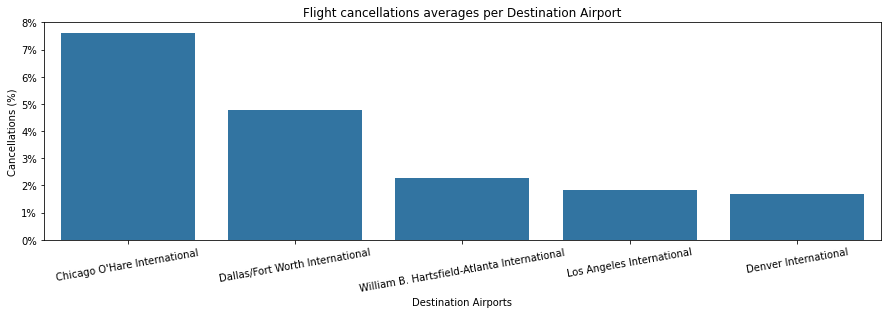

```python
plt.figure(figsize=(15,4))

AvgCancellationsPerDestAirports = top_five_destination_airports.groupby('Dest').Cancelled.mean().sort_values(ascending = False)

sb.barplot(x=AvgCancellationsPerDestAirports.index,y=AvgCancellationsPerDestAirports.values,color=base_color);
plt.gca().yaxis.set_major_formatter(PercentFormatter(1, decimals = 0))
plt.xlabel('Destination Airports')
plt.xticks([0,1,2,3,4], ["Chicago O'Hare International", 'Dallas/Fort Worth International',
                         'William B. Hartsfield-Atlanta International', 'Los Angeles International',
                         'Denver International'], rotation = 10)
plt.ylabel('Cancellations (%)')
plt.title('Flight cancellations averages per Destination Airport');
```

## Chicago O'Hare International Airport is by far the Destination airport where the most flight cancellations happen as well.

# How do Airlines compare on Flight Arrival Delay percentages?

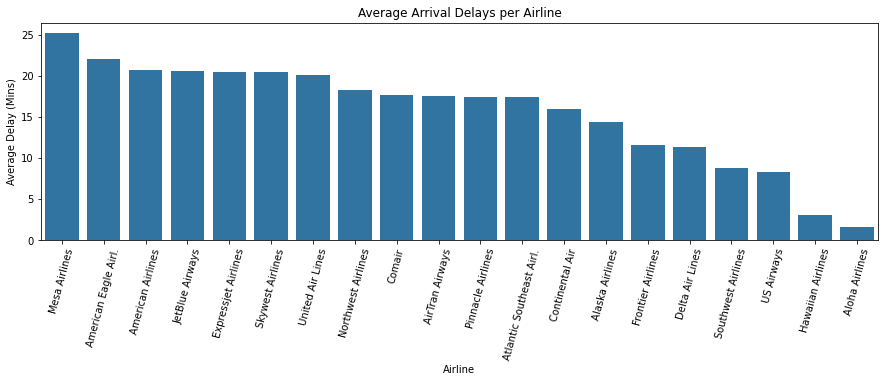

```python
plt.figure(figsize=(15,4))

ArrivalDelaysPerAirline = delaysclean.groupby('UniqueCarrierFull').ArrDelay.mean().sort_values(ascending=False)

sb.barplot(x=ArrivalDelaysPerAirline.index,y=ArrivalDelaysPerAirline.values,color=base_color)
plt.xlabel('Airline')
plt.xticks(rotation = 75)
plt.ylabel('Average Delay (Mins)')
plt.title("Average Arrival Delays per Airline");
```

## Messa Airlines ranks first at the average arrival delays too, while Aloha Airlines last.

##### Hawaiian Airlines is worth mentioning once again, as their arrival delay averages are pretty low too!

# How do Airlines compare on Flight Departure Delay percentages?

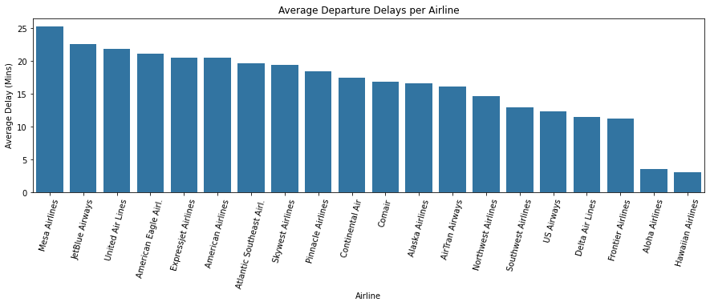

```python
plt.figure(figsize=(15,4))

DepartureDelaysPerAirline = delaysclean.groupby('UniqueCarrierFull').DepDelay.mean().sort_values(ascending=False)

sb.barplot(x=DepartureDelaysPerAirline.index,y=DepartureDelaysPerAirline.values,color=base_color)
plt.xlabel('Airline')
plt.xticks(rotation = 75)
plt.ylabel('Average Delay (Mins)')
plt.title("Average Departure Delays per Airline");
```

## Almost same story on Departure delays with Messa Airlines being first and this time Hawaiian Airlines last.

##### Aloha airlines this time is worth mentioning as they have pretty low departure delays too!

# How do Days of Week compare on Flight Arrival Delay percentages?

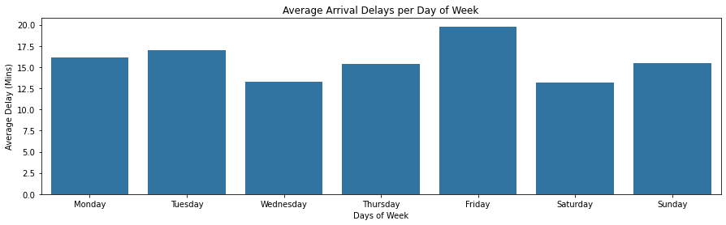

```python
plt.figure(figsize=(15,4))

MeanArrDelaysPerDoW = delaysclean.groupby('DayOfWeek')['ArrDelay'].mean()

sb.barplot(x=MeanArrDelaysPerDoW.index,y=MeanArrDelaysPerDoW.values,color=base_color)
plt.xlabel('Days of Week')
plt.ylabel('Average Delay (Mins)')
plt.title('Average Arrival Delays per Day of Week');
```

## Fridays are ranked first in Arrival delays with Tuesdays being second.

# How do Days of Week compare on Flight Departure Delay percentages?

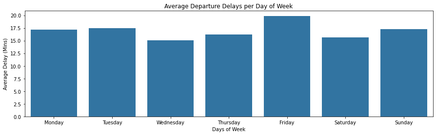

```python
plt.figure(figsize=(15,4))

MeanDepDelaysPerDoW = delaysclean.groupby('DayOfWeek')['DepDelay'].mean()

sb.barplot(x=MeanDepDelaysPerDoW.index,y=MeanDepDelaysPerDoW.values,color=base_color)
plt.xlabel('Days of Week')
plt.ylabel('Average Delay (Mins)')
plt.title('Average Departure Delays per Day of Week');
```

## Fridays are ranked first in Departure delays as well.

# How do Days of Month compare on Flight Arrival Delay percentages?

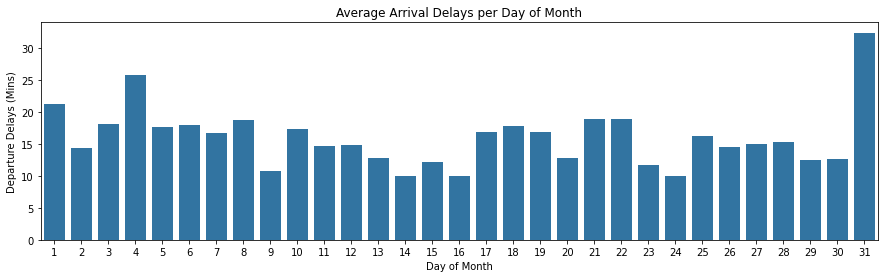

```python
plt.figure(figsize=(15,4))

MeanArrDelaysPerDoM = delaysclean.groupby('DayofMonth')['ArrDelay'].mean()

sb.barplot(x=MeanArrDelaysPerDoM.index,y=MeanArrDelaysPerDoM.values,color=base_color)
plt.xlabel('Day of Month')
plt.ylabel('Departure Delays (Mins)')
plt.title('Average Arrival Delays per Day of Month');
```

## The 31st of each month has the highest average on Arrival delays throughout the whole month with the 4th being second.